# Lab #2

WEI-XUAN HU

2024-01-29

## 1.Data Preparation

```r
# Download the package and dataset
install.packages("gapminder")
install.packages("dplyr")
```

```r
install.packages("ggplot2")
library("gapminder")

library("dplyr")
library("ggplot2")

data(gapminder)

head(gapminder, 15)
```

```
## # A tibble: 15 × 6
##    country     continent  year lifeExp      pop gdpPercap
##    <fct>       <fct>     <int>   <dbl>    <int>     <dbl>
##  1 Afghanistan Asia       1952    28.8  8425333      779.
##  2 Afghanistan Asia       1957    30.3  9240934      821.
##  3 Afghanistan Asia       1962    32.0 10267083      853.
##  4 Afghanistan Asia       1967    34.0 11537966      836.
##  5 Afghanistan Asia       1972    36.1 13079460      740.
##  6 Afghanistan Asia       1977    38.4 14880372      786.
##  7 Afghanistan Asia       1982    39.9 12881816      978.
##  8 Afghanistan Asia       1987    40.8 13867957      852.
##  9 Afghanistan Asia       1992    41.7 16317921      649.
## 10 Afghanistan Asia       1997    41.8 22227415      635.
## 11 Afghanistan Asia       2002    42.1 25268405      727.
## 12 Afghanistan Asia       2007    43.8 31889923      975.
## 13 Albania     Europe     1952    55.2  1282697     1601.
## 14 Albania     Europe     1957    59.3  1476505     1942.
## 15 Albania     Europe     1962    64.8  1728137     2313.
```

```r
# The data order countries in reverse alphabetical order
gm <- arrange(gapminder, desc(country))

# Display the first 15
head(gm, 15)
```

```
## # A tibble: 15 × 6
##    country  continent  year lifeExp      pop gdpPercap
##    <fct>    <fct>     <int>   <dbl>    <int>     <dbl>
##  1 Zimbabwe Africa     1952    48.5  3080907      407.
##  2 Zimbabwe Africa     1957    50.5  3646340      519.
##  3 Zimbabwe Africa     1962    52.4  4277736      527.
##  4 Zimbabwe Africa     1967    54.0  4995432      570.
##  5 Zimbabwe Africa     1972    55.6  5861135      799.
##  6 Zimbabwe Africa     1977    57.7  6642107      686.
##  7 Zimbabwe Africa     1982    60.4  7636524      789.
##  8 Zimbabwe Africa     1987    62.4  9216418      706.
##  9 Zimbabwe Africa     1992    60.4 10704340      693.
## 10 Zimbabwe Africa     1997    46.8 11404948      792.
## 11 Zimbabwe Africa     2002    40.0 11926563      672.
## 12 Zimbabwe Africa     2007    43.5 12311143      470.
## 13 Zambia   Africa     1952    42.0  2672000     1147.
## 14 Zambia   Africa     1957    44.1  3016000     1312.
## 15 Zambia   Africa     1962    46.0  3421000     1453.
```

## Ordering problems in a different dataset

1. Non-Alphanumeric Data:

If the data are not alphanumeric characters like special symbols or other language, the reverse order would not work.

2. Missing Values:

If there are missing values in the column used for ordering, they might affect the results.

## 2.Calculate and display the mean, median, and standard deviation

```r
# output is the mean for the dataset.
mean_lifeExp <- mean(gm$lifeExp)

mean_pop <- mean(gm$pop)

mean_gdpPercap <- mean(gm$gdpPercap)

cat("mean of Life expectancy:", mean_lifeExp, "\n")
```

```
## mean of Life expectancy: 59.47444
```

```r
cat("mean of Life Population:", mean_pop, "\n")
```

```
## mean of Life Population: 29601212
```

```r
cat("mean of Life GDPperCapita:", mean_gdpPercap, "\n")
```

```
## mean of Life GDPperCapita: 7215.327
```

```r
# output is the median for the dataset.
median_lifeExp <- median(gm$lifeExp)

median_pop <- median(gm$pop)

median_gdpPercap <- median(gm$gdpPercap)


cat("median of Life expectancy:", median_lifeExp, "\n")
```

```
## median of Life expectancy: 60.7125
```

```r
cat("median of Life Population:", median_pop, "\n")
```

```
## median of Life Population: 7023596
```

```r
cat("median of Life GDPperCapita:", median_gdpPercap, "\n")
```

```
## median of Life GDPperCapita: 3531.847
```

```r
# output is the standard deviation of the dataset.
sd_lifeExp <- sd(gm$lifeExp)

sd_pop <- sd(gm$pop)

sd_gdpPercap <- sd(gm$gdpPercap)


cat("standard deviation  of Life expectancy:", sd_lifeExp, "\n")
```

```
## standard deviation  of Life expectancy: 12.91711
```

```r
cat("standard deviation  of Life Population:", sd_pop, "\n")
```

```
## standard deviation  of Life Population: 106157897
```

```r
cat("standard deviation  of Life GDPperCapita:", sd_gdpPercap, "\n")
```

```
## standard deviation  of Life GDPperCapita: 9857.455
```

```r
# Calculate the mean values for each continent
continent_means <- gapminder %>%

  group_by(continent) %>%

  summarise(

    mean_lifeExp, mean_pop, mean_gdpPercap

  )

# print the resulting dataframe
print(continent_means)
```

```
## # A tibble: 5 × 4
##   continent mean_lifeExp  mean_pop mean_gdpPercap
##   <fct>            <dbl>     <dbl>          <dbl>
## 1 Africa            59.5 29601212.          7215.
## 2 Americas          59.5 29601212.          7215.
## 3 Asia              59.5 29601212.          7215.
## 4 Europe            59.5 29601212.          7215.
## 5 Oceania           59.5 29601212.          7215.
```

## 4.Create a scatter plot of the global average Life expectancy over time and display the first 5 records for the dataset used to build this plot. Customize the display of the plot to make it less blah.

```r
# Calculate global average life expectancy over time
global_avg_life_expectancy <- gapminder %>%

  group_by(year) %>%

  summarise(Avg_LifeExpectancy = mean(lifeExp, na.rm = TRUE))


# Create scatter plot

scatter_plot <- ggplot(global_avg_life_expectancy, aes(x = year, y = Avg_LifeExpectancy)) +

  geom_point(size = 3, color = "steelblue") +

  geom_smooth(method = "loess", se = FALSE, color = "darkred", linewidth = 1) +

  labs(

    title = "Global Average Life Expectancy Over Time",

    x = "Year",

    y = "Average Life Expectancy"

  ) +

  theme_minimal()

# Show the first 5 records of the dataset

head(global_avg_life_expectancy, 5)
```

```
## # A tibble: 5 × 2
##    year Avg_LifeExpectancy
##   <int>              <dbl>
## 1  1952               49.1
## 2  1957               51.5
## 3  1962               53.6
## 4  1967               55.7
## 5  1972               57.6
```

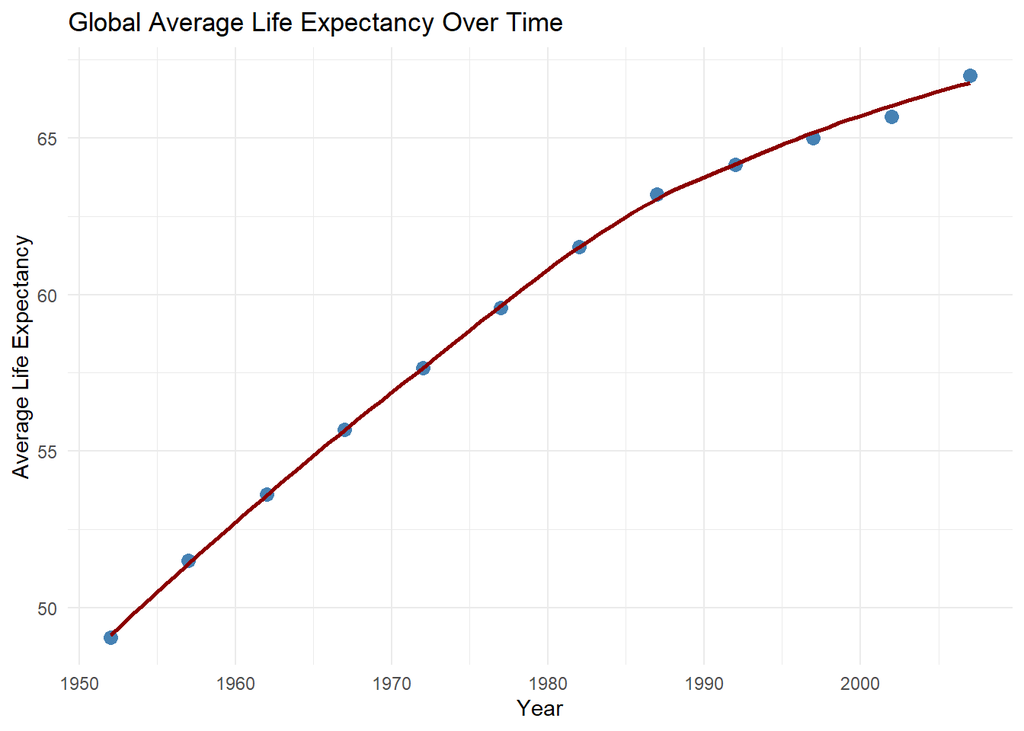

```r
# Show the scatter plot
print(scatter_plot)
```

## 5.Pull in a dataset of your choice from the datasets package that has a dataframe structure (not sure what’s available, try ?datasets). Then examine the structure of the data including: class types, header information, and dimensions.

```r
# Load "Iris" dataset
data(iris)

# Show the structure of the dataset
str(iris)
```

```
## 'data.frame':    150 obs. of  5 variables:
##  $ Sepal.Length: num  5.1 4.9 4.7 4.6 5 5.4 4.6 5 4.4 4.9 ...
##  $ Sepal.Width : num  3.5 3 3.2 3.1 3.6 3.9 3.4 3.4 2.9 3.1 ...
##  $ Petal.Length: num  1.4 1.4 1.3 1.5 1.4 1.7 1.4 1.5 1.4 1.5 ...
##  $ Petal.Width : num  0.2 0.2 0.2 0.2 0.2 0.4 0.3 0.2 0.2 0.1 ...
##  $ Species     : Factor w/ 3 levels "setosa","versicolor",..: 1 1 1 1 1 1 1 1 1 1 ...
```

```r
# Show the first few rows of the dataset
head(iris)
```

```
##   Sepal.Length Sepal.Width Petal.Length Petal.Width Species
## 1          5.1         3.5          1.4         0.2  setosa
## 2          4.9         3.0          1.4         0.2  setosa
## 3          4.7         3.2          1.3         0.2  setosa
## 4          4.6         3.1          1.5         0.2  setosa
## 5          5.0         3.6          1.4         0.2  setosa
## 6          5.4         3.9          1.7         0.4  setosa
```

```r
# Show the dimensions of the dataset
dim(iris)
```

```
## [1] 150   5
```

## 6.Calculate general summary statistics for the dataset.

```r
# Calculate general summary statistics for the "Iris" dataset
summary(iris)
```

```
##   Sepal.Length    Sepal.Width     Petal.Length    Petal.Width
##  Min.   :4.300   Min.   :2.000   Min.   :1.000   Min.   :0.100
##  1st Qu.:5.100   1st Qu.:2.800   1st Qu.:1.600   1st Qu.:0.300
##  Median :5.800   Median :3.000   Median :4.350   Median :1.300
##  Mean   :5.843   Mean   :3.057   Mean   :3.758   Mean   :1.199
##  3rd Qu.:6.400   3rd Qu.:3.300   3rd Qu.:5.100   3rd Qu.:1.800
##  Max.   :7.900   Max.   :4.400   Max.   :6.900   Max.   :2.500
##        Species
##  setosa    :50
##  versicolor:50
##  virginica :50
##
##
##
```

## 7.Calculate summary statistics for groups/subsets of the dataset (these groupings could be based on time period, species, location, etc…).

```r
# Calculate summary statistics for groups/subsets based on species
summary_by_species <- iris %>%

  group_by(Species) %>%

  summarise(

    Mean_SepalLength = mean(Sepal.Length),

    Mean_SepalWidth = mean(Sepal.Width),

    Mean_PetalLength = mean(Petal.Length),

    Mean_PetalWidth = mean(Petal.Width),

    Median_SepalLength = median(Sepal.Length),

    Median_SepalWidth = median(Sepal.Width),

    Median_PetalLength = median(Petal.Length),

    Median_PetalWidth = median(Petal.Width),

    Min_SepalLength = min(Sepal.Length),

    Min_SepalWidth = min(Sepal.Width),

    Min_PetalLength = min(Petal.Length),

    Min_PetalWidth = min(Petal.Width),

    Max_SepalLength = max(Sepal.Length),

    Max_SepalWidth = max(Sepal.Width),

    Max_PetalLength = max(Petal.Length),

    Max_PetalWidth = max(Petal.Width)

  )

# Print the summary statistics by species
# No limitation of output length
print(summary_by_species, width = Inf)
```

```
## # A tibble: 3 × 17
##   Species    Mean_SepalLength Mean_SepalWidth Mean_PetalLength Mean_PetalWidth
##   <fct>                 <dbl>           <dbl>            <dbl>           <dbl>
## 1 setosa                 5.01            3.43             1.46           0.246
## 2 versicolor             5.94            2.77             4.26           1.33
## 3 virginica              6.59            2.97             5.55           2.03
##   Median_SepalLength Median_SepalWidth Median_PetalLength Median_PetalWidth
##                <dbl>             <dbl>              <dbl>             <dbl>
## 1                5                 3.4               1.5                0.2
## 2                5.9               2.8               4.35               1.3
## 3                6.5               3                 5.55               2
##   Min_SepalLength Min_SepalWidth Min_PetalLength Min_PetalWidth Max_SepalLength
##             <dbl>          <dbl>           <dbl>          <dbl>           <dbl>
## 1             4.3            2.3             1              0.1             5.8
## 2             4.9            2               3              1               7
## 3             4.9            2.2             4.5            1.4             7.9
##   Max_SepalWidth Max_PetalLength Max_PetalWidth
##            <dbl>           <dbl>          <dbl>
## 1            4.4             1.9            0.6
## 2            3.4             5.1            1.8
## 3            3.8             6.9            2.5
```

## 8.Create 2 plots of your choice, one showing grouped data and the other showing ungrouped data. Give each plot a title and descriptive x and y axis labels. Customize at least one graphic option (color, point type, line width, etc…) on these plots.

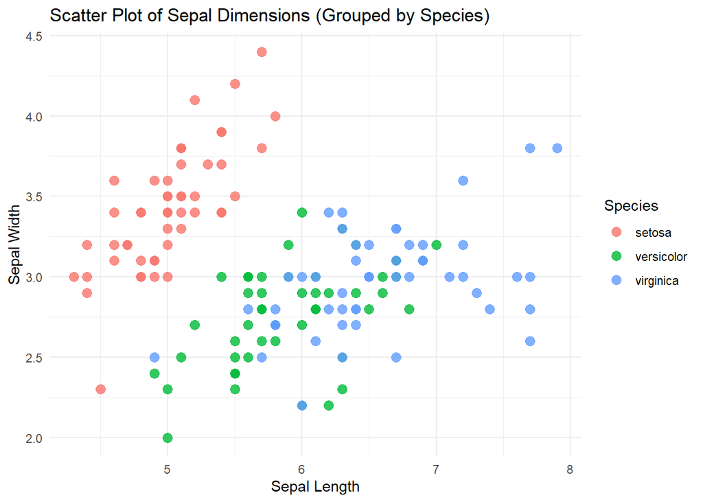

```r
# Plot 1: Grouped Data (Scatter plot)
plot_grouped <- ggplot(iris, aes(x = Sepal.Length, y = Sepal.Width, color = Species)) +

  geom_point(size = 3, alpha = 0.8) +

  labs(

    title = "Scatter Plot of Sepal Dimensions (Grouped by Species)",

    x = "Sepal Length",

    y = "Sepal Width"

  ) +

  theme_minimal()


# Plot 2: Ungrouped Data (Box plot)
plot_ungrouped <- ggplot(iris, aes(x = Species, y = Petal.Length, fill = Species)) +

  geom_boxplot(width = 0.5, alpha = 0.8) +

  labs(

    title = "Box Plot of Petal Length (Ungrouped)",

    x = "Species",

    y = "Petal Length"

  ) +

  theme_minimal()


# Display the plots
print(plot_grouped)
```

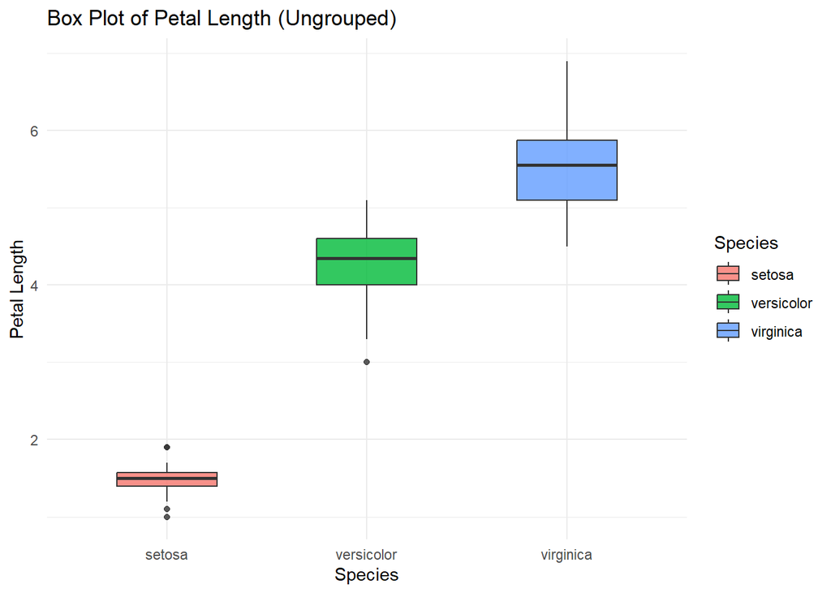

```r
print(plot_ungrouped)
```